# Ecce Signum: Illustration

# Housing Starts

This illustration examines monthly New Residential Construction (1964-2012), Housing Units Started, Single Family Units. (The four series are from the Survey of Construction of the U.S. Census Bureau, available at http://www.census.gov/construction/nrc/how_the_data_are_collected/soc.html.) We refer to the series as *starts* for short. The data corresponds to the four regions of South, West, NorthEast, and MidWest. This example illustrates modeling a multivariate series with $8$ components, estimated with both MOM and MLE methods, and the extraction of signals with two methods (direct matrix and truncated Wiener-Kolmogorov). We also show how functions of a signal, such as growth rates, can be obtained.

## Loading Packages

This code loads the data into a variable named **starts**.

```r
## wipe
rm(list=ls())
library(devtools)
```

[output not shown]

```r
library(Rcpp)

load_all(".")
```

```
## Loading sigex
```

```r
root.dir <- getwd()
```

## Enter Metadata

- We perform a four-variate analysis by fitting a structural model.
- First enter metadata, including starting date and frequency.

```r
start.date = c(1964,1)
period <- 12
```

- Next enter names of the series.
- The last argument of **sigex.load** generates a time series plot.

```r
dataALL.ts <- sigex.load(starts,start.date,period,
                         c("South","West","NE","MW"),TRUE)
```

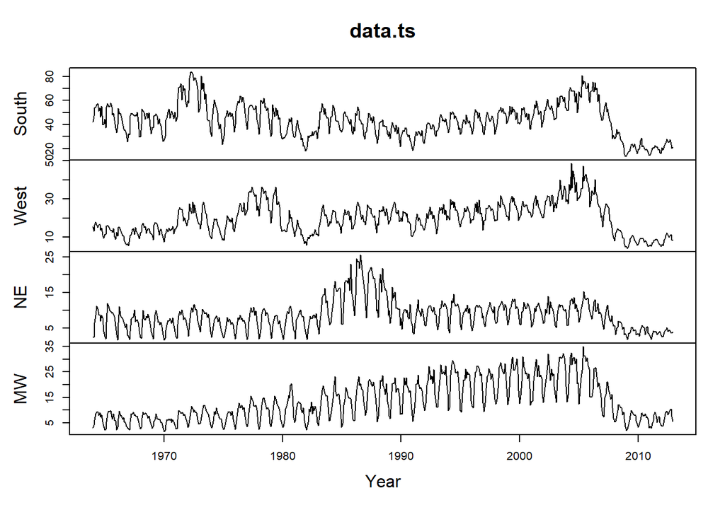

- On the basis of this plot, we decide (below) to utilize no transformation for the data.

## Select Spans and Transforms

- We have the choice of either log or no log.
- The *aggregate* option will sum across the indicated series, in case we want to analyze an aggregate. Here we set it to FALSE.
- We can also select a subcomponent of series with *subseries*.
- The *range* argument of **sigex.prep** will select a subset of dates for the time series to be analyzed.

```r
transform <- "none"
aggregate <- FALSE
subseries <- c(1,2,3,4)
begin.date <- start.date
end.date <- end(dataALL.ts)
range <- list(begin.date,end.date)
data.ts <- sigex.prep(dataALL.ts,transform,aggregate,subseries,range,TRUE)
```

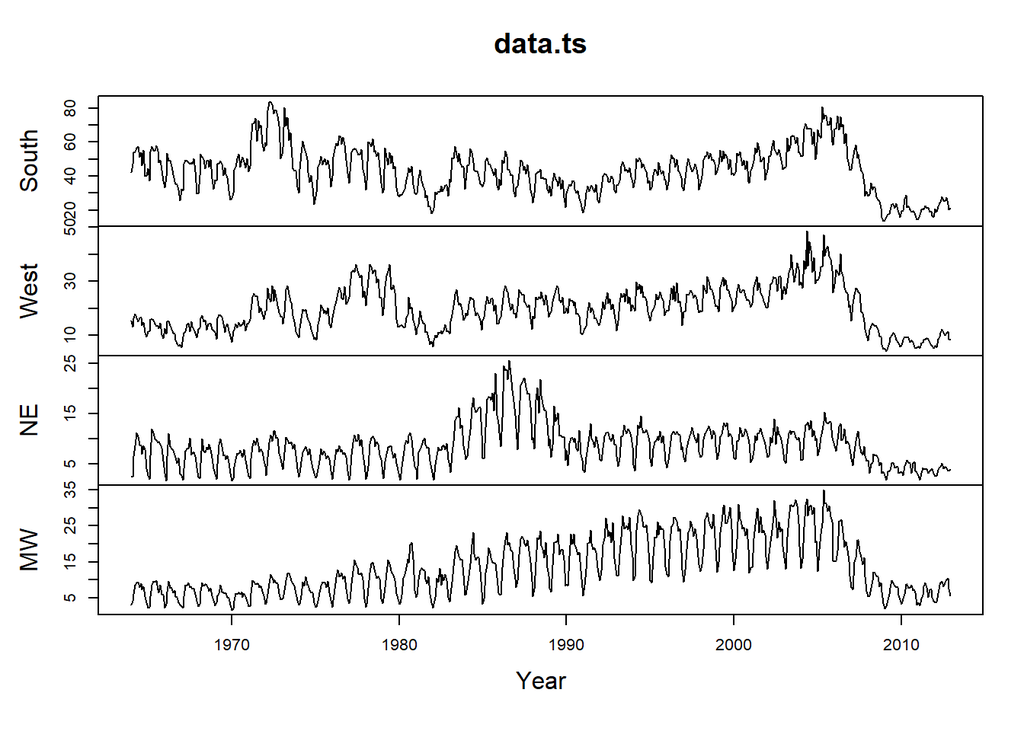

## Spectral Exploratory Analysis

- In order to get an idea about model specification, we can examine spectral estimates, using **sigex.specar**.
- We can look at raw data or differenced data (growth rates).

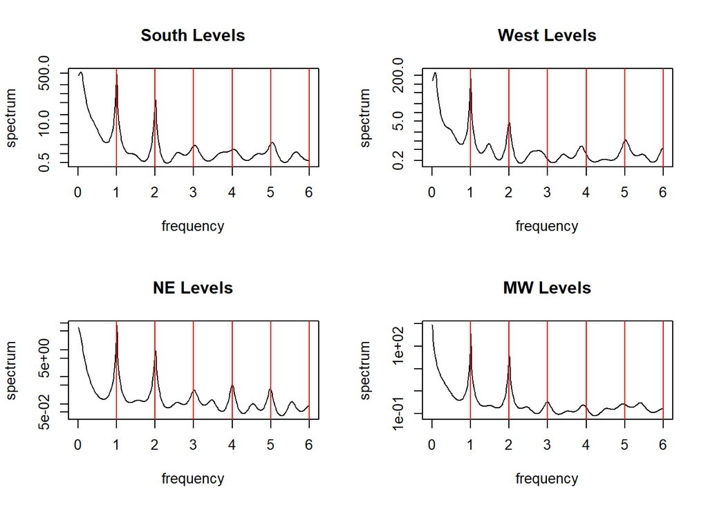

```r
# raw data
par(mfrow=c(2,2))
for(i in subseries) {   sigex.specar(data.ts,FALSE,i,period) }
```

```r
dev.off()
```

- From the raw data, it seems that trend differencing is appropriate.

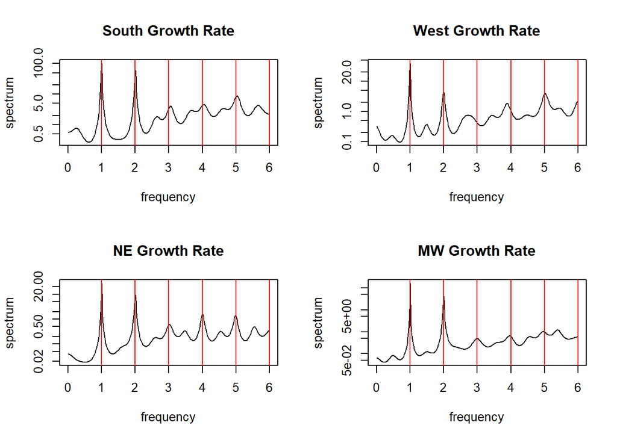

```r
# growth rates
par(mfrow=c(2,2))
for(i in subseries) {   sigex.specar(data.ts,TRUE,i,period) }
```

```r
dev.off()
```

- From both sets of spectral plots, there seems to be strong seasonality.
- The degree of seasonal persistence appears to be different at the six seasonal frequencies.

## Model Declaration

- Exploratory analysis indicates we should consider a model with trend and seasonal effects.
- To model the differing strengths of seasonality, we use six latent atomic seasonal processes.
- We begin by defining dimension $N$ and sample size $T$.

```r
N <- dim(data.ts)[2]
T <- dim(data.ts)[1]
```

- Next, we define the latent components.

```r
mdl <- NULL
mdl <- sigex.add(mdl,seq(1,N),"arma",c(0,0),NULL,"trend",c(1,-2,1))
mdl <- sigex.add(mdl,seq(1,N),"arma",c(0,0),NULL,"first seasonal",c(1,-sqrt(3),1))
mdl <- sigex.add(mdl,seq(1,N),"arma",c(0,0),NULL,"second seasonal",c(1,-1,1))
mdl <- sigex.add(mdl,seq(1,N),"arma",c(0,0),NULL,"third seasonal",c(1,0,1))
mdl <- sigex.add(mdl,seq(1,N),"arma",c(0,0),NULL,"fourth seasonal",c(1,1,1))
mdl <- sigex.add(mdl,seq(1,N),"arma",c(0,0),NULL,"fifth seasonal",c(1,sqrt(3),1))
mdl <- sigex.add(mdl,seq(1,N),"arma",c(0,0),NULL,"sixth seasonal",c(1,1))
mdl <- sigex.add(mdl,seq(1,N),"arma",c(0,0),NULL,"irregular",1)
```

- Each of the eight latent processes is labeled, and has a distinct differencing polynomial, whose application produces a full-rank white noise.
- The multiple calls to **sigex.add** adds each latent process consecutively into the existing model.
- The second argument indicates the rank configuration; setting *vrank* equal to seq(1,N) ensures a full rank covariance matrix.
- The third argument gives the model type as *arma*; the order $p=0$, $q=0$ indicates a white noise.
- The sixth argument associates a label.
- The last argument is for the scalar differencing operator $\delta^{(k)} (z)$, expressed as a vector of coefficients.

```r
mdl <- sigex.meaninit(mdl,data.ts,0)
```

- There are no regressors specified, but we still need to call **sigex.meaninit** so that the time trend polynomial is set up correctly.
- The last argument gives the order of this time trend polynomial. In this case it will be automatically determined from the various differencing operators $\delta^{(k)} (z)$ of the latent processes.

## Model Estimation

- Now we will fit the model, and check the fit.
- The first step is to construct pilot estimates via the Method-of-Moments (MOM).

### MOM Fitting

- First, we define a new model object *mdl.mom*.
- The MOM estimates are obtained through **sigex.momfit**.

```r
mdl.mom <- mdl
constraint <- NULL
par.default <- sigex.default(mdl.mom,data.ts,constraint)
par.mom <- sigex.momfit(data.ts,par.default,mdl.mom)
psi.mom <- sigex.par2psi(par.mom,mdl.mom)
```

- The value of the divergence is 6329.1070444.

### MOM Residual Analysis

- Next, we can examine the residuals.

```r
resid.mom <- sigex.resid(psi.mom,mdl.mom,data.ts)[[1]]
resid.mom <- sigex.load(t(resid.mom),start(data.ts),
                        frequency(data.ts),colnames(data.ts),TRUE)
```

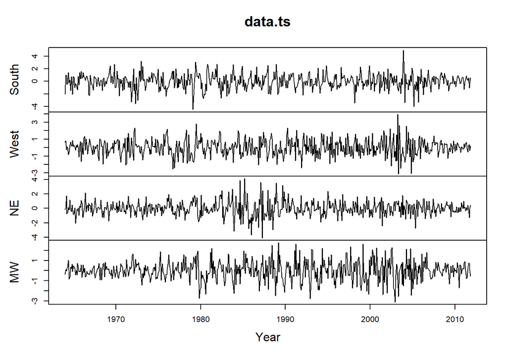

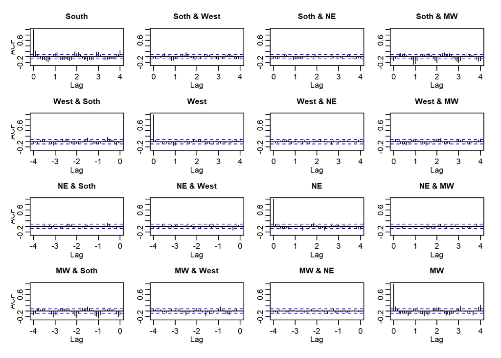

```r
resid.acf <- acf(resid.mom,lag.max=4*period,plot=TRUE)$acf
```

- A substantial degree of serial dependence remains.

### Reduced Rank Analysis

- We can examine the condition numbers.

```r
log(sigex.conditions(data.ts,psi.mom,mdl.mom))
```

```
##      [,1]          [,2]          [,3]         [,4]
## eta2    0 -1.0171093770  -0.741120678  -1.31768897
## eta2    0 -2.0992339540  -1.928099136 -35.59909389
## eta2    0 -1.2944202752          -Inf -36.19095592
## eta2    0 -0.0772582525  -0.415666036         -Inf
## eta2    0 -0.6977358965          -Inf         -Inf
## eta2    0 -7.8512850198 -28.998527363 -33.70560807
## eta2    0 -0.6386239872          -Inf         -Inf
## eta2    0 -0.0002575913  -0.006716595  -0.05467899
```

- All six seasonal latent processes seem to have reduced rank covariance matrices, indicating various types of seasonal co-integration.
- We can modify the initial model to one that has reduced rank components, by using **sigex.reduce**.

```r
thresh <- -6.22
reduced.mom <- sigex.reduce(data.ts,par.mom,mdl.mom,thresh,TRUE)
mdl.mom <- reduced.mom[[1]]
par.mom <- reduced.mom[[2]]
psi.mom <- sigex.par2psi(par.mom,mdl.mom)
```

- Here the threshold $-6.22$ and the updated model is stored in *reduced.mom*, a list object.
- The first item in the list contains the updated information for the model, viz., the new rank configurations.
- The new reduced rank model has divergence 6292.8412344.

### Further Residual Analysis

- We check the residuals of the reduced rank model.

```r
resid.mom <- sigex.resid(psi.mom,mdl.mom,data.ts)[[1]]
resid.mom <- sigex.load(t(resid.mom),start(data.ts),
                        frequency(data.ts),colnames(data.ts),TRUE)
```

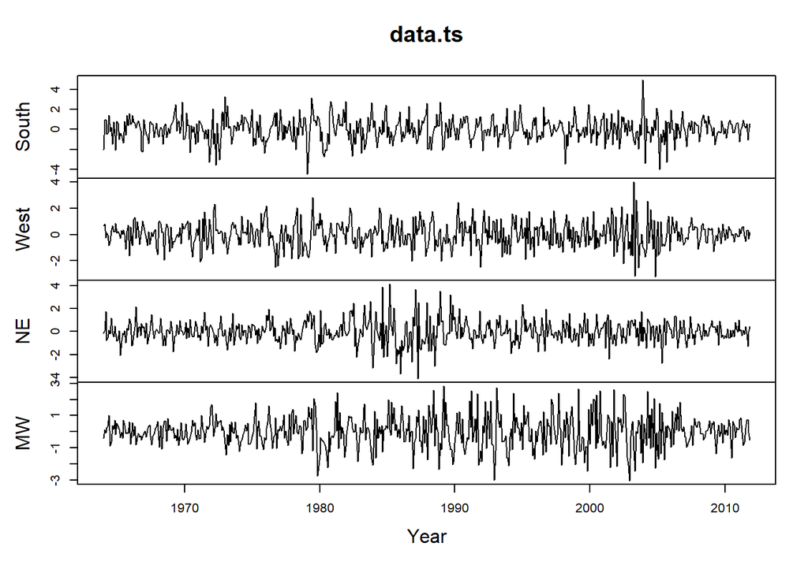

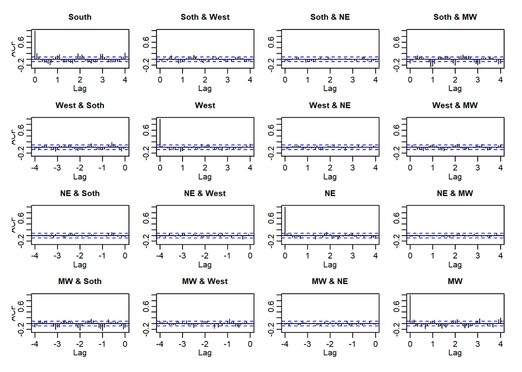

```r
resid.acf <- acf(resid.mom,lag.max=4*period,plot=TRUE)$acf
```

- Also the new condition numbers can be checked.

```r
log(sigex.conditions(data.ts,psi.mom,mdl.mom))
```

```
##      [,1]          [,2]         [,3]         [,4]
## eta2    0 -1.017109e+00 -0.741120678  -1.31768897
## eta2    0 -2.099234e+00 -1.928099136 -35.59909389
## eta2    0 -1.294420e+00         -Inf         -Inf
## eta2    0 -7.725825e-02 -0.415666036         -Inf
## eta2    0 -6.977359e-01         -Inf         -Inf
## eta2    0 -3.583621e+01         -Inf -36.54176512
## eta2    0 -6.386240e-01         -Inf         -Inf
## eta2    0 -2.575913e-04 -0.006716595  -0.05467899
```

- Portmanteau and normality tests are also provided.

```r
sigex.portmanteau(resid.mom,4*period,length(psi.mom))
```

```
## [1] 1955.874    0.000
```

```r
sigex.gausscheck(resid.mom)
```

```
## [1] 2.909151e-04 2.867016e-01 3.870890e-08 6.918020e-04
```

- Finally, we bundle this initial fit away.

```r
analysis.mom <- sigex.bundle(data.ts,transform,mdl.mom,psi.mom)
```

### MLE Fitting

- Now we consider fitting the model via MLE, using the MOM as initial estimates.
- The model and initial parameters are obtained from the MOM bundle.

```r
data.ts <- analysis.mom[[1]]
mdl <- analysis.mom[[3]]
psi.mom <- analysis.mom[[4]]
par.mom <- sigex.psi2par(psi.mom,mdl,data.ts)
```

- Next, we set up the constraints (there are none).

```r
constraint <- NULL
psi.mle <- sigex.par2psi(par.mom,mdl)
```

- Fitting this reduced rank model can take a substantial amount of time, because there are $67$ pre-parameters to be estimated.
- Therefore this part is commented out, because the calculations can take several hours. Instead, we load *psi.mle* computed previously.

```r
#fit.mle <- sigex.mlefit(data.ts,par.mom,constraint,mdl,"bfgs",debug=TRUE)
psi.mle <- c(0.430604758988307, 0.138843971938441, 0.211034753655249, 0.122497565015475,
             0.273961955347927, 0.83829841362335, -2.19718581249183, -4.85906104866881,
             -6.69696771334971, -6.13282806492413, 1.12175825784647, 0.289882305425559,
             0.873677616319397, -0.745293003402034, -0.754732471766407, -0.498376140705462,
             -2.42443529609759, -4.72941611158525, -6.52941280216317, 0.459400674188665,
             0.208306224143506, 1.24487637498583, -1.388883213613, -0.526433078980047,
             -3.90916616951099, -5.82829964996699, -0.169794036259361, 0.22214398081366,
             0.152889428361731, -0.00908575947899202, -0.00318543112970812,
             0.0884748269673841, -2.73579660752933, -3.66216778737483, -4.49261642825817,
             -0.112193904428172, -0.203557855469594, -0.164528907998198, -0.680285482020193,
             0.244662042202419, -3.28673706196714, -6.93954034182091, 1.05554783833862,
             -0.16328976555996, 0.311473085983565, -4.85381927837337, -0.244998596862816,
             0.0508029104468634, 0.194372016161389, 1.14475061810928, -0.253386348374559,
             -3.61493340437869, -6.83641878016894, 0.0921157226442518, 0.0283709627836627,
             -0.0389611692363272, 0.0109437749519264, 0.0358792010736619,
             0.245040148693726, 2.69734505562902, 1.07979552299194, -0.0671443528547337,
             0.302809384452077, 0.000724801053757517, 0.000779888484070904,
             -2.68663079304438e-05, 0.000373610017630947)
par.mle <- sigex.psi2par(psi.mle,mdl,data.ts)
```

- The value of the divergence is 6152.6070599.
- This divergence is substantially better than that of the MOM estimate, cf. 6292.8412344.

### MLE Residual Analysis

- Next, we can examine the residuals. Much of the correlation is gone.

```r
resid.mle <- sigex.resid(psi.mle,mdl,data.ts)[[1]]
resid.mle <- sigex.load(t(resid.mle),start(data.ts),
                        frequency(data.ts),colnames(data.ts),TRUE)
```

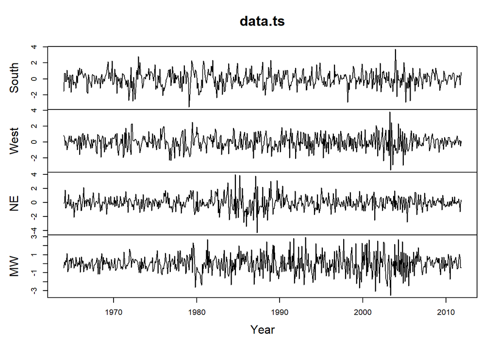

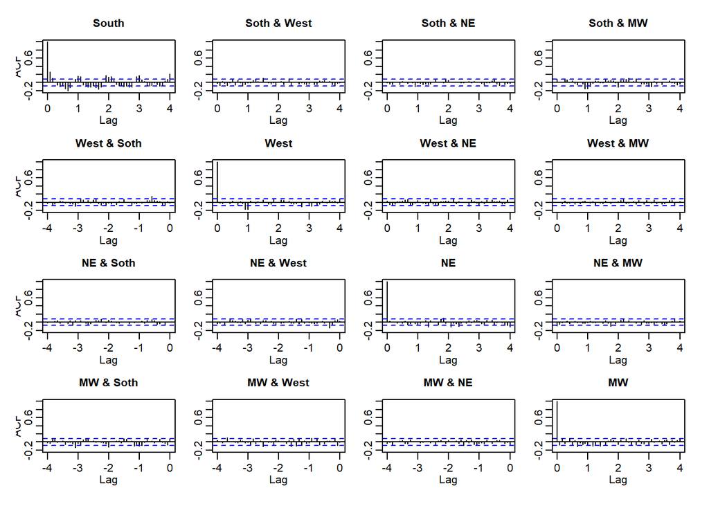

```r
resid.acf <- acf(resid.mle,lag.max=4*period,plot=TRUE)$acf
```

- We can also examine the condition numbers. We see values of $-\infty$ (or very large negative values) corresponding to the complement of the rank configuration.

```r
log(sigex.conditions(data.ts,psi.mle,mdl))
```

```
##      [,1]        [,2]         [,3]        [,4]
## eta2    0 -1.29631497  -1.04000328 -1.37321646
## eta2    0 -2.61106918  -2.24666400        -Inf
## eta2    0 -0.89130496         -Inf        -Inf
## eta2    0 -0.07027696  -0.25162257        -Inf
## eta2    0 -0.39585799         -Inf        -Inf
## eta2    0        -Inf         -Inf        -Inf
## eta2    0 -0.91810063 -35.35865401        -Inf
## eta2    0 -0.04188263  -0.01306605 -0.05913488
```

```r
sigex.portmanteau(resid.mle,4*period,length(psi.mle))
```

```
## [1] 1297.34    0.00
```

```r
sigex.gausscheck(resid.mle)
```

```
## [1] 2.303617e-03 1.564666e-01 6.576116e-09 9.598481e-04
```

- Finally, we bundle the results.

```r
analysis.mle <- sigex.bundle(data.ts,transform,mdl,psi.mle)
```

## Signal Extraction

- The next stage of analysis is signal extraction, and both the matrix method and the WK method are illustrated.
- First we load up the MLE bundle.

```r
data.ts <- analysis.mle[[1]]
mdl <- analysis.mle[[3]]
psi <- analysis.mle[[4]]
param <- sigex.psi2par(psi,mdl,data.ts)
```

### Direct Matrix Approach

```r
signal.trend <- sigex.signal(data.ts,param,mdl,1)
signal.seas <- sigex.signal(data.ts,param,mdl,seq(2,7))
signal.sa <- sigex.signal(data.ts,param,mdl,c(1,8))
```

- The second step is to compute the extractions using **sigex.extract**.
- The output is a list object, with first item corresponding to a $T \times N$ matrix of signal extractions. The second and third items of the list give upper and lower bounds of confidence intervals, based on $\pm 2$ square root signal extraction MSE.

```r
extract.trend <- sigex.extract(data.ts,signal.trend,mdl,param)
extract.seas <- sigex.extract(data.ts,signal.seas,mdl,param)
extract.sa <- sigex.extract(data.ts,signal.sa,mdl,param)
```

- Next, it is important to re-integrate fixed regression effects using **sigex.fixed**.

```r
reg.trend <- NULL
for(i in 1:N) {
  reg.trend <- cbind(reg.trend,sigex.fixed(data.ts,mdl,i,param,"Trend")) }
```

- Next, we generate displays with a call to **sigex.graph**.
- Blue is the seasonal adjustment, red is the trend, and green is the seasonal.
- In the display we illustrate how the seasonal component can be plotted with a vertical displacement.
- Shading around each value of the extraction indicates the upper and lower bounds for confidence intervals.

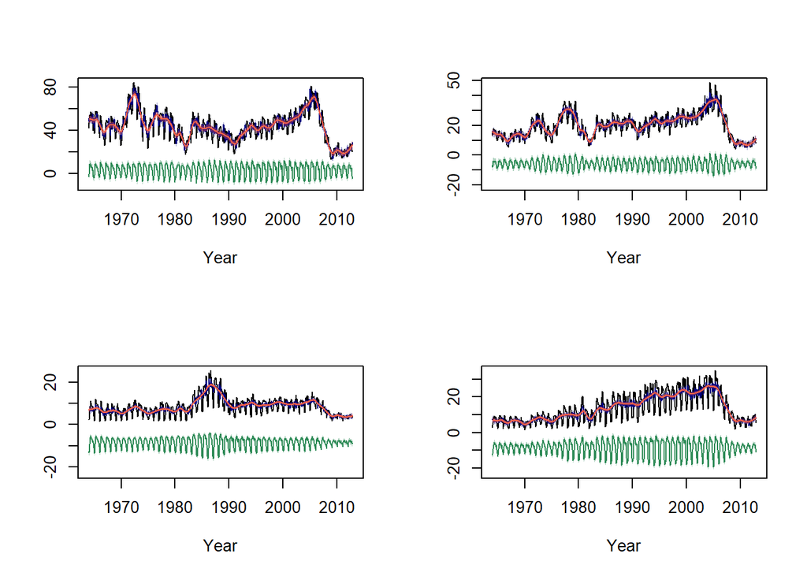

```r
trendcol <- "tomato"
seascol <- "seagreen"
sacol <- "navyblue"
fade <- 60
par(mfrow=c(2,2))
for(i in 1:N)
{
  plot(data.ts[,i],xlab="Year",ylab="",ylim=c(min(data.ts[,i])-25,max(data.ts[,i])),lwd=1)
  sigex.graph(extract.sa,reg.trend,begin.date,period,i,0,sacol,fade)
  sigex.graph(extract.trend,reg.trend,begin.date,period,i,0,trendcol,fade)
  sigex.graph(extract.seas,NULL,begin.date,period,i,min(data.ts[,i])-10,seascol,fade)
}
```

```r
dev.off()
```

- Next, we can examine spectral density estimates of the extractions.

```r
## spectral diagnostics: trend
par(mfrow=c(2,2))
for(i in 1:N)
{
  sigex.specar(ts(extract.trend[[1]],frequency=period,names=colnames(data.ts)),FALSE,i,period)
}
```

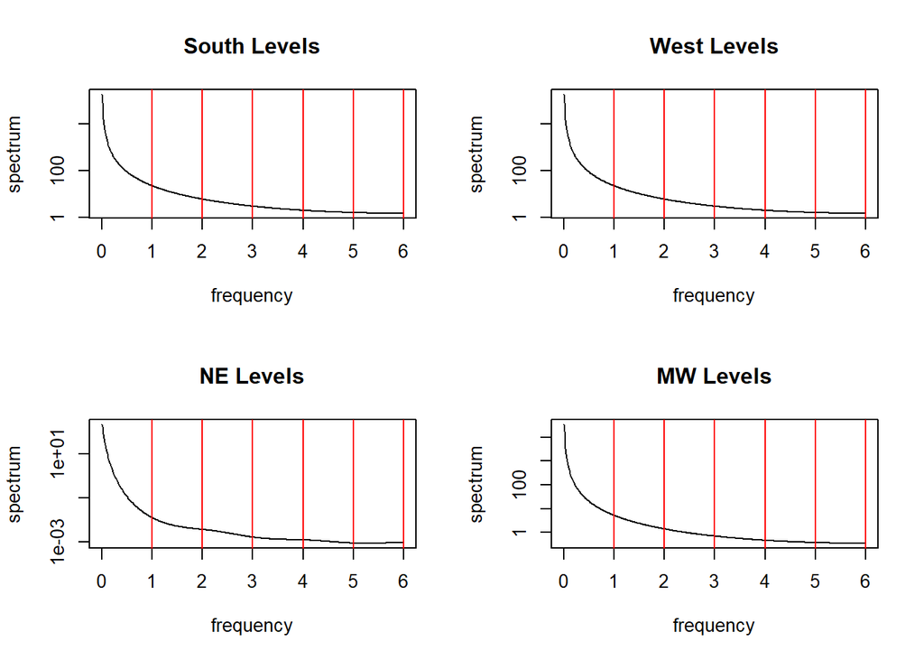

```r
dev.off()
```

```r
## spectral diagnostics: sa
par(mfrow=c(2,2))
for(i in 1:N)
{
  sigex.specar(ts(extract.sa[[1]],frequency=period,names=colnames(data.ts)),FALSE,i,period)
}
```

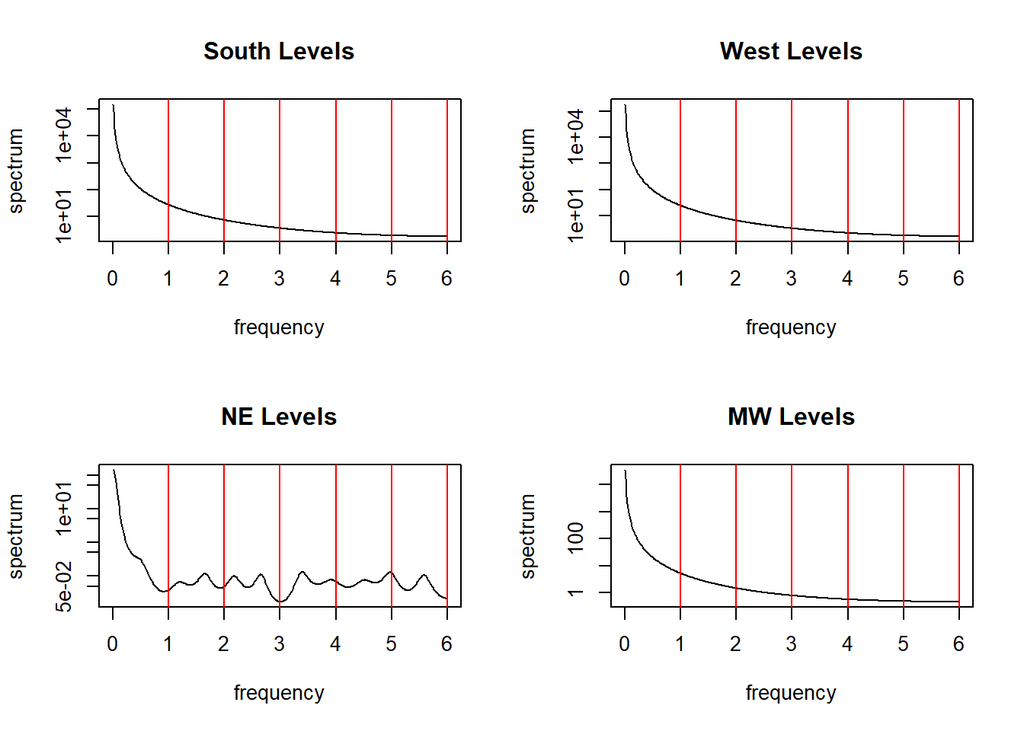

```r
dev.off()
```

### Filter Analysis

- We can examine filter coefficients and frequency response functions through **sigex.getfrf**, which can also plot the real portions.
- The *grid* argument corresponds to a mesh of frequencies in $[0, \pi]$, and the fourth argument of **sigex.getfrf** indicates the combination of components desired.
- We examine the trend, seasonal, and seasonal adjustment.

```r
grid <- 200
par(mfrow=c(4,4))
frf.trend <- sigex.getfrf(data.ts,param,mdl,1,TRUE,grid)
```

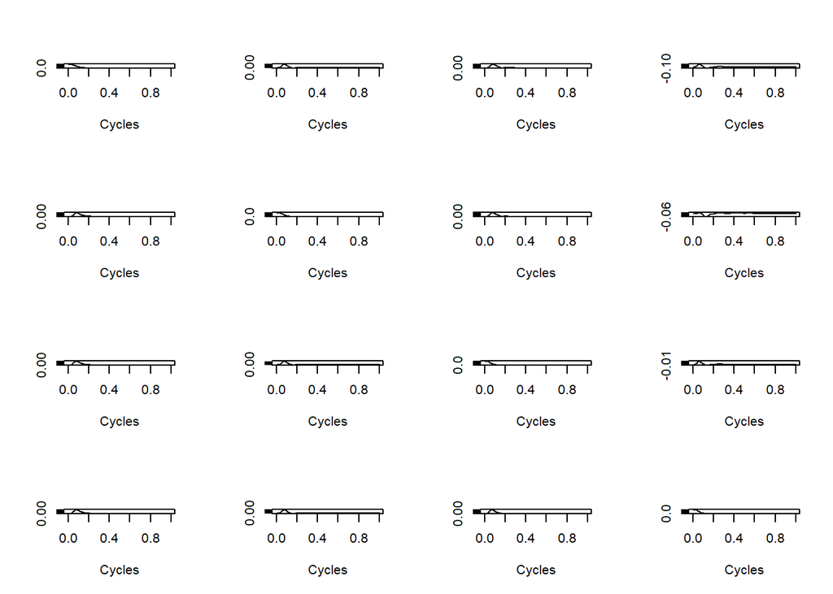

```r
dev.off()
```

```r
par(mfrow=c(4,4))
frf.seas <- sigex.getfrf(data.ts,param,mdl,seq(2,7),TRUE,grid)
```

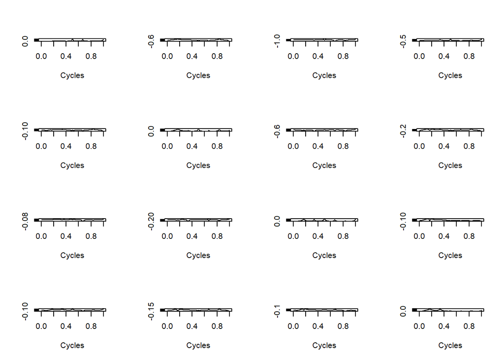

```r
dev.off()
```

```r
par(mfrow=c(4,4))
frf.sa <- sigex.getfrf(data.ts,param,mdl,c(1,8),TRUE,grid)
```

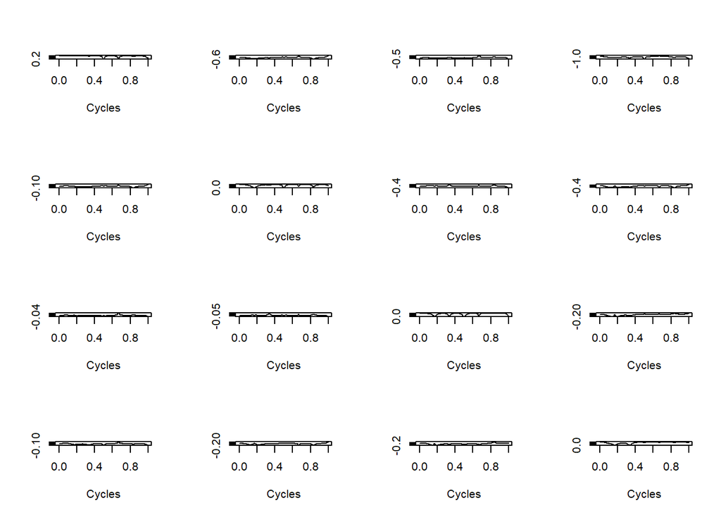

```r
dev.off()
```

- We can also examine the filter coefficients, using **sigex.wk**.
- The *target* argument indicates that no linear combination of the signal is being considered here.
- *len* is set to $50$, so that the indices of the filter run from $-50$ up to $50$.

```r
len <- 50
target <- array(diag(N),c(N,N,1))
par(mfrow=c(4,4))
wk.trend <- sigex.wk(data.ts,param,mdl,1,target,TRUE,grid,len)
```

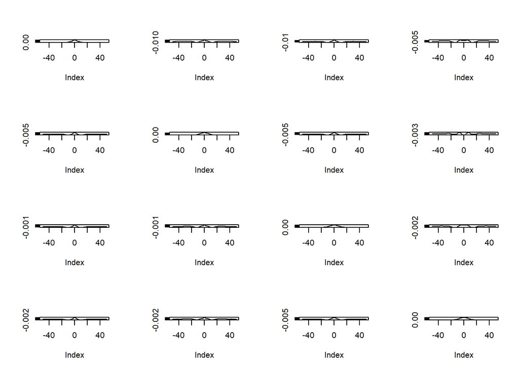

```r
dev.off()
```

```r
par(mfrow=c(4,4))
wk.seas <- sigex.wk(data.ts,param,mdl,seq(2,7),target,TRUE,grid,len)
```

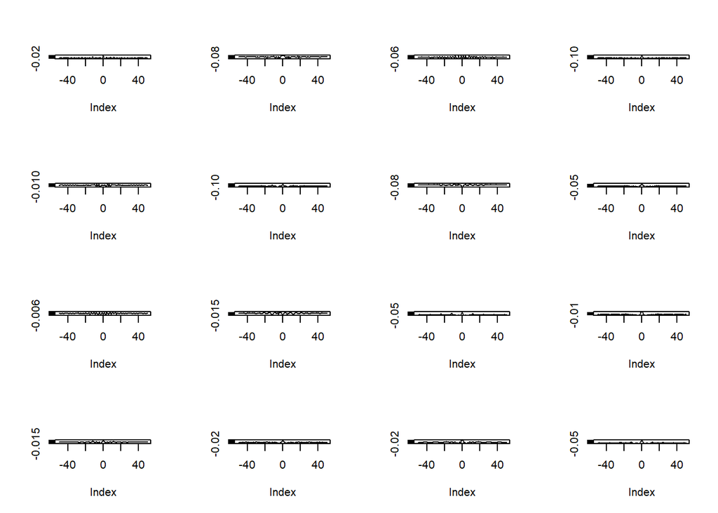

```r
dev.off()
```

```r
par(mfrow=c(4,4))
wk.sa <- sigex.wk(data.ts,param,mdl,c(1,8),target,TRUE,grid,len)
```

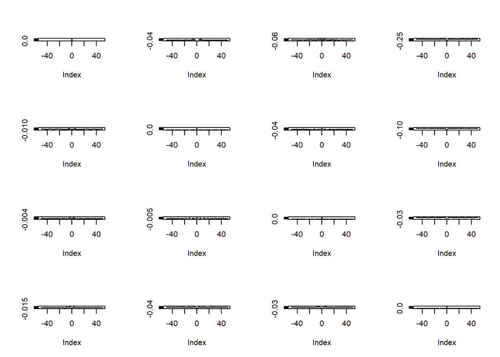

```r
dev.off()
```

### Cast Extension Approach to Signal Extraction

- Now we consider a second method for signal extraction, based on forecast and aftcast extension of the time series, using the function **sigex.wkextract**.
- We set the *grid* parameter to determine the number of mesh points in the interval $[-\pi,\pi]$ used as a Riemann approximation of the integral (in the frequency response function).
- *window* specifies that the filter will be truncated to length $101$ (equal to twice *window* plus one) at the sample boundaries – only $50$ forecasts and aftcasts will be generated.
- The *horizon* parameter corresponds to the number of desired aftcasts and forecasts of the signal used in the application. Here we set to $0$, because we don’t want to forecast the signal outside the sample span.
- *target* is the array storing the coefficients used to construct other linear combinations of the signal.

```r
grid <- 7000
window <- 50
horizon <- 0
target <- array(diag(N),c(N,N,1))
```

- We will generate extractions for trend, seasonal, and seasonal adjustment, and compare to results from the matrix method above.
- The fourth argument in these function calls is *sigcomps*, and parallels the prior calls of **sigex.signal**.
- Note that in the matrix approach we used two calls in succession (**sigex.signal** followed by **sigex.extract**), but here there is a single call with output in the same list format as that provided by **sigex.extract**.

```r
extract.trend2 <- sigex.wkextract(psi,mdl,data.ts,1,target,grid,window,horizon,TRUE)
extract.seas2 <- sigex.wkextract(psi,mdl,data.ts,seq(2,7),target,grid,window,horizon,TRUE)
extract.sa2 <- sigex.wkextract(psi,mdl,data.ts,c(1,8),target,grid,window,horizon,TRUE)
```

- One method of comparison is looking at signal extraction MSEs.
- We examine the trend and seasonal adjustment components in turn: the casted trend extraction MSE is red, and the casted seasonal adjustment is blue.

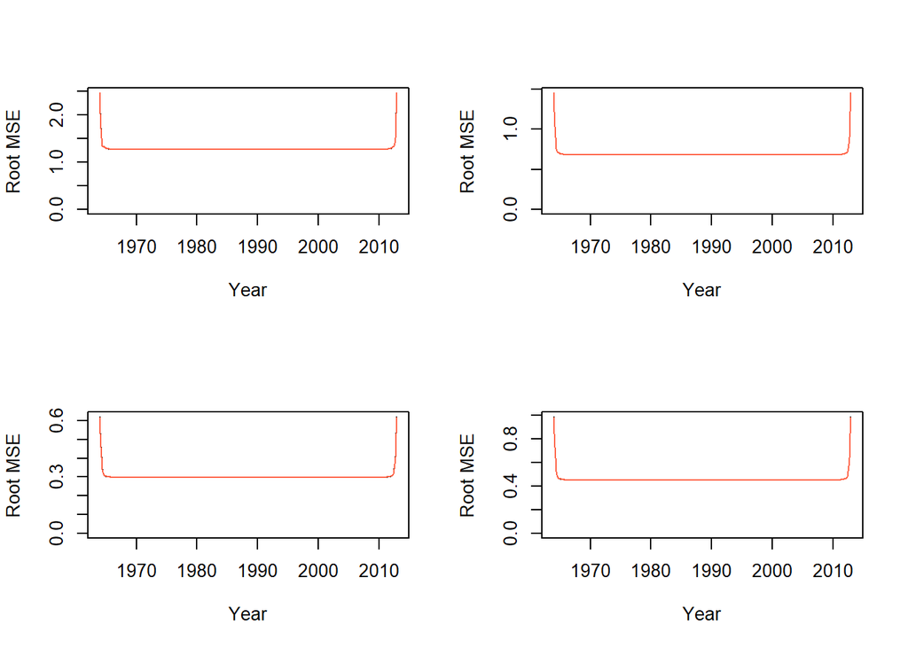

```r
par(mfrow=c(2,2))
for(subseries in 1:N)
{
  ex.true <- (extract.trend[[1]][,subseries]-extract.trend[[3]][,subseries])/2
  ex.approx <- (extract.trend2[[1]][,subseries]-extract.trend2[[3]][,subseries])/2
  plot(ts(ex.true,start=begin.date,frequency=period),ylab="Root MSE",xlab="Year",ylim=c(0,max(ex.true)))
  lines(ts(ex.approx,start=begin.date,frequency=period),col=trendcol)
}
```

```r
dev.off()
```

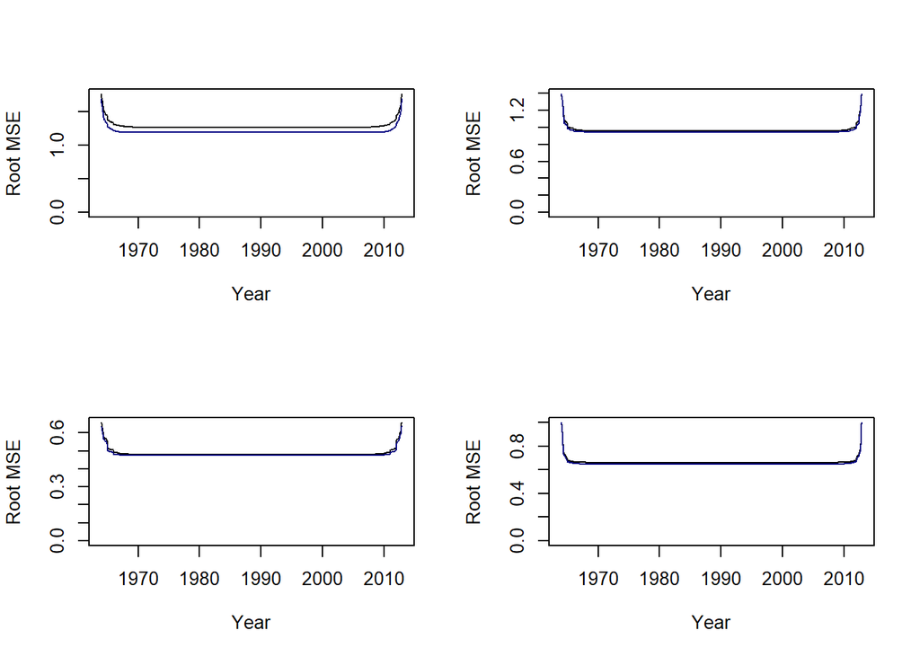

```r
par(mfrow=c(2,2))
for(subseries in 1:N)
{
  ex.true <- (extract.sa[[1]][,subseries]-extract.sa[[3]][,subseries])/2
  ex.approx <- (extract.sa2[[1]][,subseries]-extract.sa2[[3]][,subseries])/2
  plot(ts(ex.true,start=begin.date,frequency=period),ylab="Root MSE",xlab="Year",ylim=c(0,max(ex.true)))
  lines(ts(ex.approx,start=begin.date,frequency=period),col=sacol)
}
```

```r
dev.off()
```

### Trend Growth Rate

- Finally, we examine extraction of the trend growth rate.
- The first code block extracts the trend growth rate and MSE directly from the output of **sigex.signal** stored in *signal.trend*.
- The growth rate polynomial *gr.poly* is set to c(1,-1).

```r
gr.poly <- c(1,-1)
p <- length(gr.poly)-1
gr.mat <- t(rev(gr.poly)) %x% diag(N)
mse.trend <- array(signal.trend[[2]],c(N,T,N,T))
mse.trend.gr <- array(0,c(N,N,T-p))
trend.gr <- array(0,c(T-p,N))
trend.est <- extract.trend[[1]] + reg.trend
for(t in (p+1):T)
{
  trend.gr[t-p,] <- gr.mat %*% matrix(t(trend.est[(t-p):t,]),ncol=1)
  mse.trend.gr[,,t-p] <- gr.mat %*% matrix(mse.trend[,(t-p):t,,(t-p):t],c(N*(p+1),N*(p+1))) %*% t(gr.mat)
}
trend.gr <- ts(rbind(array(NA,c(p,N)),trend.gr),
               start=begin.date,frequency=period,names=colnames(data.ts))
extract.trendgr <- list(trend.gr,trend.gr,trend.gr)
for(k in 1:N)
{
  extract.trendgr[[2]][,k] <- extract.trendgr[[2]][,k] + 2*sqrt(c(rep(NA,p),mse.trend.gr[k,k,]))
  extract.trendgr[[3]][,k] <- extract.trendgr[[3]][,k] - 2*sqrt(c(rep(NA,p),mse.trend.gr[k,k,]))
}
```

- This is the trend growth rate based on the matrix filter, and the results are plotted.

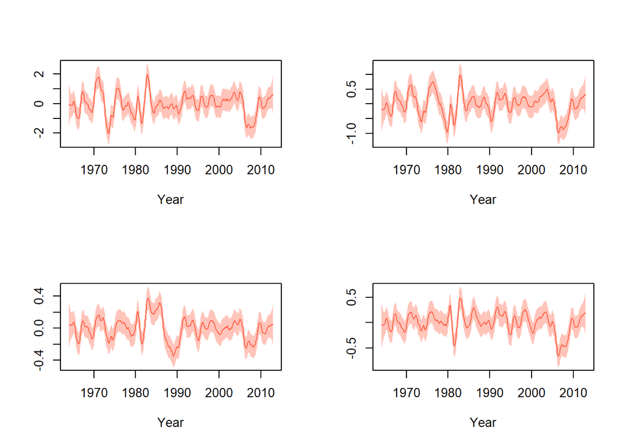

```r
par(mfrow=c(2,2))
for(i in 1:N)
{
  plot(data.ts[,i],xlab="Year",ylab="",ylim=c(min(extract.trendgr[[3]][,i],na.rm=TRUE),
                                              max(extract.trendgr[[2]][,i],na.rm=TRUE)),lwd=1,col=0)
  sigex.graph(extract.trendgr,NULL,begin.date,period,i,0,trendcol,fade)
}
```

```r
dev.off()
```

- Next, we do the calculation another way using the casted trend extraction.

```r
grid <- 70000     # need large grid value to get accuracy
window <- 100
horizon <- 0
gr.array <- array(t(gr.poly) %x% diag(N),c(N,N,p+1))
reg.gr <- array(0,c(T,N))
for(k in 1:N) { reg.gr[,k] <- filter(reg.trend[,k],gr.poly,method="convolution",sides=1) }
```

- We first compute and plot the trend growth rate.

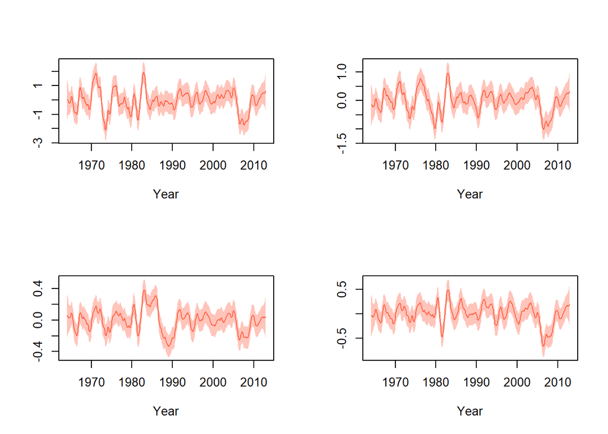

```r
extract.trendgr2 <- sigex.wkextract(psi,mdl,data.ts,1,gr.array,grid,window,horizon,TRUE)
par(mfrow=c(2,2))
for(i in 1:N)
{
  plot(data.ts[,i],xlab="Year",ylab="",ylim=c(min(extract.trendgr2[[3]][,i]+reg.gr[,i],na.rm=TRUE),
                                              max(extract.trendgr2[[2]][,i]+reg.gr[,i],na.rm=TRUE)),lwd=1,col=0)
  sigex.graph(extract.trendgr2,reg.gr,begin.date,period,i,0,trendcol,fade)
}
```

```r
dev.off()
```

- Then we compute and plot the seasonal adjustment growth rate.

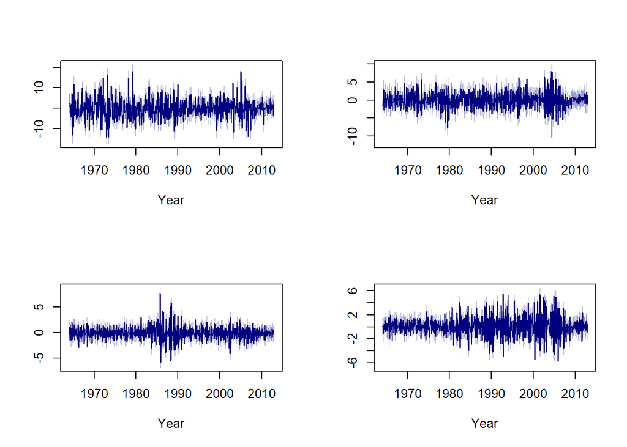

```r
extract.sagr2 <- sigex.wkextract(psi,mdl,data.ts,c(1,8),gr.array,grid,window,horizon,TRUE)
par(mfrow=c(2,2))
for(i in 1:N)
{
  plot(data.ts[,i],xlab="Year",ylab="",ylim=c(min(extract.sagr2[[3]][,i]+reg.gr[,i],na.rm=TRUE),
                                              max(extract.sagr2[[2]][,i]+reg.gr[,i],na.rm=TRUE)),lwd=1,col=0)
  sigex.graph(extract.sagr2,reg.gr,begin.date,period,i,0,sacol,fade)
}
```

```r
dev.off()
```

- We observe that both techniques produce comparable growth rate extractions.
- The uncertainty is appropriately calculated, and indicated with shading.